# Homework 2

2025 Fall EXST 7151

Author

Karthik Thrikkadeeri

Published

October 5, 2025

**Question:**

A random sample of 18 2‐year‐old girls is drawn from a child care center, and their heights are measured: 44.1 38.6 38.2 27.2 21.1 53.8 28.0 41.8 23.6 39.2 42.6 36.5 29.5 28.3 25.9 52.9 19.1 29.2

1. Assume the heights in the population of 2 year old girls are normally distributed with unknown mean $\mu$ and known standard deviation 10 inches. Suppose your prior distribution for $\mu$ is normal with mean 30 and standard deviation 6.
   1. Get the posterior distribution for $\mu$.
   2. Get the posterior mean, variance, sd, 5th and 95th percentile for $\mu$.
2. Assume the heights in the population of 2 year old girls are normally distributed with known mean $\mu = 32$ inches and unknown variance $\sigma^2$. Suppose your prior distribution for $\sigma^2$ is inverse gamma(2,20).
   1. Get the posterior distribution for $\sigma^2$.
   2. Get the posterior mean, variance, sd, 5th and 95 th percentile for $\sigma^2$.

Use exact values, not Monte Carlo approximation.

**Solution:**

# 1 Unknown mean

Setting up:

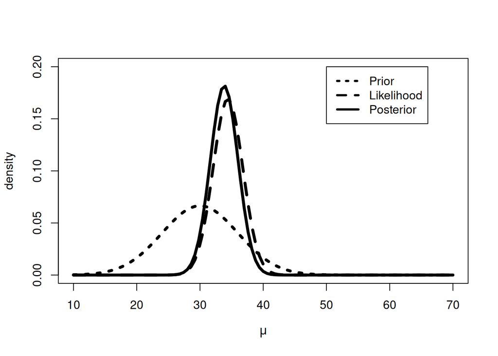

```r
mu_0 <- 30
sigma_0_sq <- 6^2
sigma_sq <- 10^2
y <- c(44.1, 38.6, 38.2, 27.2, 21.1, 53.8, 28.0, 41.8, 23.6, 39.2, 42.6, 36.5,
       29.5, 28.3, 25.9, 52.9, 19.1, 29.2)

# use the distribution of ybar
y_bar <- mean(y)
n <- length(y)
sigma_sq <- sigma_sq/n

sigma_n_sq <- 1/(1/sigma_0_sq + 1/sigma_sq)
mu_n <- (mu_0/sigma_0_sq + y_bar/sigma_sq)*sigma_n_sq

curve(dnorm(x, mu_0, sqrt(sigma_0_sq)), # R function defines in mean and sd, not mean and var
      from = 10, to = 70,
      ylim = c(0, 0.2),
      lty = 3, lwd = 4,
      xlab = expression(mu),
      ylab = "density")
curve(dnorm(x, y_bar, sqrt(sigma_sq)),
      add = TRUE, lty = 2, lwd = 4)
curve(dnorm(x, mu_n, sqrt(sigma_n_sq)),
      add = TRUE, lty = 1, lwd = 4)
legend(50, 0.2, c("Prior", "Likelihood", "Posterior"),
       lty = 3:1, lwd = 3)
```

## 1.1 Posterior distribution

```r
mu_n; sigma_n_sq
```

```
[1] 33.83102
```

```
[1] 4.812834
```

The posterior distribution is a $Normal(33.831016, 4.8128342)$.

## 1.2 Posterior summaries

The posterior mean, variance, sd, and 5th and 95th percentiles for $\mu$ are:

```r
perc5 <- qnorm(0.05, mu_n, sqrt(sigma_n_sq))
perc95 <- qnorm(0.95, mu_n, sqrt(sigma_n_sq))

mu_n; sigma_n_sq; sqrt(sigma_n_sq); perc5; perc95
```

```
[1] 33.83102
```

```
[1] 4.812834
```

```
[1] 2.193817
```

```
[1] 30.22251
```

```
[1] 37.43952
```

# 2 Unknown variance

Setting up:

```r
# using n from before

mu <- 32
alpha <- 2; beta <- 20
alpha_n <- alpha + n/2
beta_n <- beta + sum((y - mu)^2)/2
```

## 2.1 Posterior distribution

```r
alpha_n; beta_n
```

```
[1] 11
```

```
[1] 960.38
```

The posterior distribution is a $inv-gamma(11, 960.38)$.

## 2.2 Posterior summaries

The posterior mean, variance, sd, and 5th and 95th percentiles for $\sigma^2$ are:

```r
post_mean <- (beta_n/(alpha_n - 1))
post_var <- (beta_n^2/((alpha_n - 1)^2 * (alpha_n-2)))
post_sd <- sqrt(post_var)

# Percentiles for Inv-Gamma: use Gamma quantiles since
# 1/X ~ Gamma(shape = alpha, rate = beta)
post_5 <- 1 / qgamma(1 - 0.05, shape = alpha_n, rate = beta_n)
post_95 <- 1 / qgamma(1 - 0.95, shape = alpha_n, rate = beta_n)

post_mean; post_var; post_sd; post_5; post_95
```

```
[1] 96.038
```

```
[1] 1024.811
```

```
[1] 32.01267
```

```
[1] 56.61877
```

```
[1] 155.6782
```